# Next-generation sequencing bulk segregant analysis with QTLseqr

Ben N. Mansfeld and Rebecca Grumet

2017-10-18

Abstract

Originally developed in the early 1990’s, Bulk Segregant Analysis (BSA) has since been an extremely useful tool for rapidly identifying markers in a genomic region associated with a trait of interest. QTL-seq is a relatively new and rapid way for performing bulk segregant analysis using next-generation sequencing data. However, no easy-to-use and multi-system compatible algorithms for performing this analysis are readily available.We developed the QTLseqr R package to allow for quick identification of genomic regions associated with traits of interest by combining two methods for bulk segregant analysis, $G'$ and $\Delta SNP\text{-}index$, described by Magwene et al. (2011) and Tagaki et al. (2013), respectively. Plotting of data is implemented in ggplot2 which allows for high-quality and customizable figures. QTLseqr package version 0.3.0

# Standard workflow

**If you use QTLseqr in published research, please cite:**

> Mansfeld B.N. and Grumet R, QTLseqr: An R package for bulk segregant analysis with next-generation sequencing *Journal* 2017, **other info**

## Quick Start

Here are the basic steps required to run and plot QTLseq and $G'$ analysis

```r
#load the package
library("QTLseqr")

#Set sample and file names
HighBulk <- "SRR834931"
LowBulk <- "SRR834927"
file <- "SNPs_from_GATK.table"

#Choose which chromosomes will be included in the analysis (i.e. exclude smaller contigs)
Chroms <- paste0(rep("Chr", 12), 1:12)

#Import SNP data from file
df <-
    importFromGATK(
        file = file,
        highBulk = HighBulk,
        lowBulk = LowBulk,
        chromList = Chroms
     )

#Filter SNPs based on some criteria
df_filt <-
    filterSNPs(
        SNPset = df,
        refAlleleFreq = 0.20,
        minTotalDepth = 100,
        maxTotalDepth = 400,
        minSampleDepth = 40,
        minGQ = 99
    )


#Run G' analysis
df_filt <- runGprimeAnalysis(
    SNPset = df_filt,
    windowSize = 1e6,
    outlierFilter = "deltaSNP")

#Plot
plotQTLStats(SNPset = df_filt, var = "deltaSNP", plotThreshold = TRUE, q = 0.01)
plotQTLStats(SNPset = df_filt, var = "Gprime", plotThreshold = TRUE, q = 0.01)

#export summary CSV
getQTLTable(SNPset = df_filt, alpha = 0.01, export = TRUE, fileName = "my_BSA_QTL.csv")
```

## Input data

QTLseqr currently only supports table format SNP data exported from the VariantsToTable function built in to GATK. We hope to support import from SAMtools/BCFtools as well as a simple table format, soon.

## Importing SNPs from GATK

Working directly with the [GATK best practices guide](https://software.broadinstitute.org/gatk/best-practices/bp_3step.php?case=GermShortWGS) for whole genome sequence should result in a VCF that is compatible with QTLseqr. In general the workflow suggested by GATK is per-sample variant calling followed by joint genotyping across samples. This will produce a VCF file that includes **BOTH** bulks, each with a different sample name (here SRR834927 and SRR834931), one SNP for example:

*info column removed for brevity

| CHROM | POS | ID | REF | ALT | QUAL | FILTER | INFO | FORMAT | SRR834927 | SRR834931 |
| --- | --- | --- | --- | --- | --- | --- | --- | --- | --- | --- |
| Chr1 | 31071 | . | A | G | 1390.44 | PASS | ..*… | GT:AD:DP:GQ:PL | 0/1:34,36:70:99:897,0,855 | 0/1:26,22:48:99:522,0,698 |

GATK have provided a fast VCF parser, the [VariantsToTable](https://software.broadinstitute.org/gatk/documentation/tooldocs/current/org_broadinstitute_gatk_tools_walkers_variantutils_VariantsToTable.php) tool, that extracts the necessary fields for easy use in downstream analysis.

We highly recommend reading [What is a VCF and how should I interpret it?](http://gatkforums.broadinstitute.org/gatk/discussion/1268/what-is-a-vcf-and-how-should-i-interpret-it) for more information on GATK VCF Fields and Genotype Fields

Though the use of GATK’s VariantsToTable function is out of the scope of this vignette, the syntax for use with QTLseqr should look something like this:

```bash
java -jar GenomeAnalysisTK.jar \
-T VariantsToTable \
-R ${REF} \
-V ${NAME} \
-F CHROM -F POS -F REF -F ALT \
-GF AD -GF DP -GF GQ -GF PL \
-o ${NAME}.table
```

Where `${REF}` is the reference genome file and `${NAME}` is VCF file you wish to parse.

To run QTLseqr successfully, the required VCF fields `(-F)` are CHROM (Chromosome) and POS (Position). the required Genotype fields `(-GF)` are AD (Allele Depth), DP (Depth). Recommended fields are REF (Reference allele) and ALT (Alternative allele) Recommended Genotype fields are PL (Phred-scaled likelihoods) and GQ (Genotype Quality).

### Import function

The `importFromGATK` function imports SNP data from the output of the VariantsToTable function in GATK. After importing the data, the function then calculates total reference allele frequency for both bulks together, the SNP index for each bulk, and the delta SNP index.

To demonstrate the use of this function we will load the Yang et al. (2013) data file.

```r
library("QTLseqr")
rawData <- system.file("extdata", "Yang_et_al_2013.table", package = "QTLseqr", mustWork = TRUE)
```

If you have your own data you can simply refer to it directly:

```r
rawData <- "C:/PATH/TO/MY/DIR/My_BSA_data.table"
```

We define the sample name for each of the bulks. This should corrispond to the sample names in the VCF returned by GATK. We also define a vector of the chromosomes to be included in the analysis (i.e. exclude smaller contigs), In this case, Chr1, Chr2 … Chr12.

```r
HighBulk <- "SRR834931"
LowBulk <- "SRR834927"
Chroms <- paste0(rep("Chr", 12), 1:12)
```

We then use the `importFromGATK` function to import the raw data. After importing the data, the function then calculates total reference allele frequency for both bulks together, the $SNP\text{-}index$ for each SNP in each bulk and the $\Delta SNP\text{-}index$ and returns a data frame.

$$Reference\ allele\ frequency = \frac{Ref\ allele\ depth_{HighBulk} + Ref\ allele\ depth_{LowBulk}}{Total\ read\ depth\ for\ both\ bulks}$$

$$SNP\text{-}index_{per\ bulk} = \frac{Alternate\ allele\ depth}{Total\ read\ depth}$$
$$\Delta SNP\text{-}index = SNP \text{-} index_{High Bulk} - SNP\text{-}index_{Low Bulk}$$

Let’s import

```r
#import data
df <-
    importFromGATK(
        file = rawData,
        highBulk = HighBulk,
        lowBulk = LowBulk,
        chromList = Chroms
     )
```

### Loaded data frame

The loaded data frame should look like this:

```r
head(df)
```

```
##   CHROM   POS REF ALT DP.HIGH AD_REF.HIGH AD_ALT.HIGH GQ.HIGH
## 1  Chr1 31071   A   G      48          26          22      99
## 2  Chr1 31478   C   T      74          40          34      99
## 3  Chr1 33667   A   G      53          24          29      99
## 4  Chr1 34057   C   T      55          29          26      99
## 5  Chr1 35239   A   C     100          40          60      99
## 6  Chr1 38389   T   C      82          42          40      99
##   SNPindex.HIGH DP.LOW AD_REF.LOW AD_ALT.LOW GQ.LOW SNPindex.LOW   REF_FRQ
## 1     0.4583333     70         34         36     99    0.5142857 0.5084746
## 2     0.4594595     86         34         52     99    0.6046512 0.4625000
## 3     0.5471698     68         20         48     99    0.7058824 0.3636364
## 4     0.4727273     78         38         40     99    0.5128205 0.5037594
## 5     0.6000000     61         25         36     99    0.5901639 0.4037267
## 6     0.4878049     78         36         42     99    0.5384615 0.4875000
##       deltaSNP
## 1 -0.055952381
## 2 -0.145191703
## 3 -0.158712542
## 4 -0.040093240
## 5  0.009836066
## 6 -0.050656660
```

Let’s review the column headers:

- CHROM - The chromosome this SNP is in
- POS - The position on the chromosome in nt
- REF - The reference allele at that position
- ALT - The alternate allele
- DP.HIGH - The read depth at that position in the high bulk
- AD_REF.HIGH - The allele depth of the reference allele in the high bulk
- AD_ALT.HIGH - The alternate allele depth in the the high bulk
- GQ.HIGH - The genotype quality score, (how confident we are in the genotyping)
- SNPindex.HIGH - The calculated SNP-index for the high bulk
- Same as above for the low bulk
- REF_FRQ - The reference allele frequency as defined above
- deltaSNP - The $\Delta SNP\text{-}index$ as defined above

## Filtering SNPs

Now that we have loaded the data into R we can start cleaning it up by filtering some of the low confidence SNPs. While GATK has its own filtering tools, QTLseqr offers some options for filtering that may help reduce noise and improve results. Filtering is mainly based on read depth for each SNP, such that we can try to elliminate SNPs with low confidence, due to low coverage, and SNPs that may be in repetitive regions and thus have inflated read depth.

### Read depth histograms

One way to assess filtering thresholds is by plotting histograms of the read depths. We can get an idea of where to draw our thresholds. We’ll use the ggplot2 package for this purpose, but you could use base R to plot as well.

Lets look at total read depth for example:

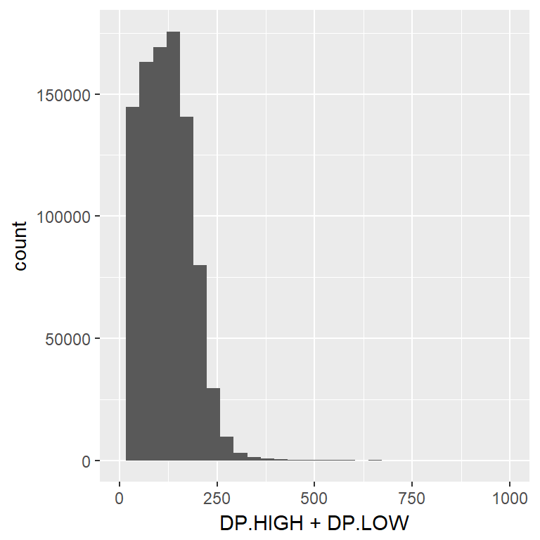

```r
library("ggplot2")
ggplot(data = df) +
    geom_histogram(aes(x = DP.HIGH + DP.LOW)) +
    xlim(0,1000)
```

…or look at total reference allele frequency:

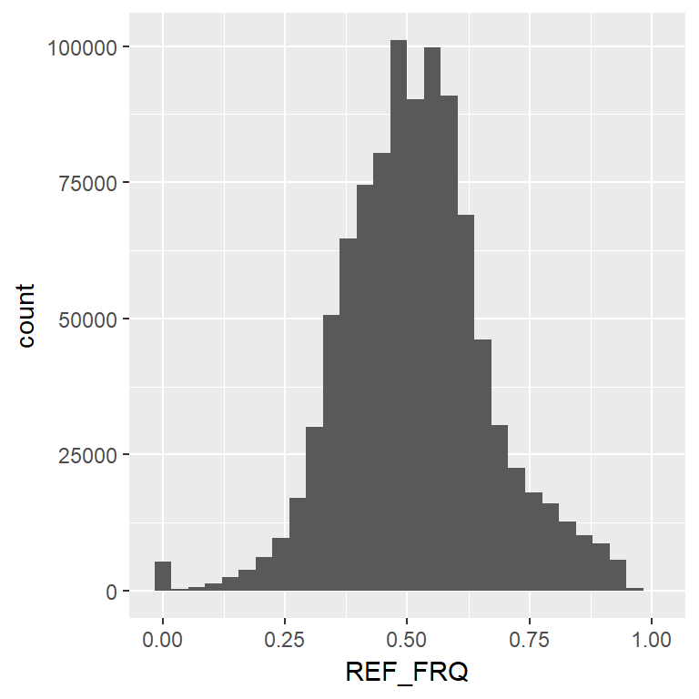

```r
ggplot(data = df) +
    geom_histogram(aes(x = REF_FRQ))
```

### Using the filterSNPs function

Now that we have an idea about our read depth distribution we can filter out low confidence SNPS. In general we recommend filtering extremely low and high coverage SNPs, either in both bulks (`minTotalDepth/maxTotalDepth`) and/or in each bulk separately (`minSampleDepth`). We have the option to filter based on reference allele frequency (`refAlleleFreq`), this removes SNPs that for some reason are over- or under-represented in *BOTH* bulks. We can also use the GATK GQ score (Genotype Quality) to filter out low confidence SNPs. If the `verbose` paramater is set to `TRUE` (default) the function will report the numbers of SNPs filtered in each step.

```r
df_filt <-
    filterSNPs(
        SNPset = df,
        refAlleleFreq = 0.20,
        minTotalDepth = 100,
        maxTotalDepth = 400,
        minSampleDepth = 40,
        minGQ = 99,
        verbose = TRUE
    )
```

```
## Filtering by reference allele frequency: 0.2 <= REF_FRQ <= 0.8
## ...Filtered 59754 SNPs
## Filtering by total sample read depth: Total DP >= 100
## ...Filtered 378814 SNPs
## Filtering by total sample read depth: Total DP <= 400
## ...Filtered 744 SNPs
## Filtering by per sample read depth: DP >= 40
## ...Filtered 4729 SNPs
## Filtering by Genotype Quality: GQ >= 99
## ...Filtered 6677 SNPs
## Original SNP number: 969487, Filtered: 450718, Remaining: 518769
```

This step is quick and we can go back and plot some histograms to see if we are happy with the results, and we can quickly re-run the filtering step if not.

## Running the analysis

The analysis in QTLseqr is an implementation of both pipelines for bulk segregant analysis, $G'$ and $\Delta SNP\text{-}index$, described by Magwene et al. (2011) and Tagaki et al. (2013), respectively. We recommend reading both papers to fully understand the conciderations and math behind the analysis. Here, we will breifly summarize the steps performed by the main analysis function, `runGprimeAnalysis`.

The following steps are performed:

1. First the number of SNPs within the sliding window are counted.
2. A tricube-smoothed $\Delta SNP\text{-}index$ is calculated within the set window size.
3. Genome-wide G statistics are calculated by `getG`. $G$ is defined by the equation:

   $$G = 2 * ∑ n_i * ln(\frac{obs(n_i)}{exp(n_i)})$$

   Where for each SNP, $n_i$ from i = 1 to 4 corresponds to the reference and alternate allele depths for each bulk, as described in the following table:

   | Allele | High Bulk | Low Bulk |
   | --- | --- | --- |
   | Reference | $n_1$ | $n_2$ |
   | Alternate | $n_3$ | $n_4$ |

   …and $obs(n_i)$ are the observed allele depths as described in the data frame. `getG` calculates the G statistic using expected values assuming read depth is equal for all alleles in both bulks:
   $$exp(n_1) = \frac{(n_1 + n_2)*(n_1 + n_3)}{(n_1 + n_2 + n_3 + n_4)}$$
   $$exp(n_2) = \frac{(n_2 + n_1)*(n_2 + n_4)}{(n_1 + n_2 + n_3 + n_4)}$$
   $$exp(n_3) = \frac{(n_3 + n_1)*(n_3 + n_4)}{(n_1 + n_2 + n_3 + n_4)}$$
   $$exp(n_4) = \frac{(n_4 + n_2)*(n_4 + n_3)}{(n_1 + n_2 + n_3 + n_4)}$$
4. G’ - A tricube-smoothed G statistic is predicted by constant local regression within each chromosome using the `tricubeStat` function. This works as a weighted average across neighboring SNPs that accounts for Linkage disequilibrium (LD) while minizing noise attributed to SNP calling errors. G values for neighboring SNPs within the window are weighted by physical distance from the focal SNP.
5. P-values are estimated based using the non-parametric method described by Magwene et al. 2011 with the function `getPvals`. Breifly, using the natural log of $G'$ a median absolute deviation (MAD) is calculated. The $G'$ set is trimmed to exclude outlier regions (i.e. QTL) based on Hampel’s rule. An alternate method for filtering out QTL that we propose is using absolute $\Delta SNP\text{-}index$ values greater than a set threshold (default = 0.1) to filter out potential QTL. An estimation of the mode of the trimmed set is calculated using the `mlv` function from the package modeest. Finally, the mean and variance of the set are estimated using the median and mode and p-values are estimated from a log normal distribution.
6. Negative Log10- and Benjamini-Hochberg adjusted p-values are calculated using `p.adjust`.

Let’s run the function:

```r
df_filt <- runGprimeAnalysis(df_filt,
    windowSize = 1e6,
    outlierFilter = "deltaSNP",
    filterThreshold = 0.1)
```

```
## Counting SNPs in each window...
## Calculating tricube smoothed delta SNP index...
## Calculating G and G' statistics...
## Estimating the mode of a trimmed G prime set using the 'modeest' package...
## Calculating p-values...
```

As this is window is using a tricube-smoothing kernel the window size *can* be much larger than you might expect. We however choose a window size of 1Mb for the sliding window analysis, for a discussion about window size we recommend reading Magwene et al. (2011). In general larger windows will produced smoother data. The functions making these calculations are rather fast, so we recommend testing several window sizes for your data, and deciding on the optimal size.

Some additional columns are added to the filtered data frame:

```r
head(df_filt)
```

```
##   CHROM   POS REF ALT DP.HIGH AD_REF.HIGH AD_ALT.HIGH GQ.HIGH
## 1  Chr1 31071   A   G      48          26          22      99
## 2  Chr1 31478   C   T      74          40          34      99
## 3  Chr1 33667   A   G      53          24          29      99
## 4  Chr1 34057   C   T      55          29          26      99
## 5  Chr1 35239   A   C     100          40          60      99
## 6  Chr1 38389   T   C      82          42          40      99
##   SNPindex.HIGH DP.LOW AD_REF.LOW AD_ALT.LOW GQ.LOW SNPindex.LOW   REF_FRQ
## 1     0.4583333     70         34         36     99    0.5142857 0.5084746
## 2     0.4594595     86         34         52     99    0.6046512 0.4625000
## 3     0.5471698     68         20         48     99    0.7058824 0.3636364
## 4     0.4727273     78         38         40     99    0.5128205 0.5037594
## 5     0.6000000     61         25         36     99    0.5901639 0.4037267
## 6     0.4878049     78         36         42     99    0.5384615 0.4875000
##       deltaSNP nSNPs tricubeDeltaSNP          G   Gprime    pvalue
## 1 -0.055952381   881     -0.07365553 0.35697092 1.919586 0.4670188
## 2 -0.145191703   881     -0.07365807 3.38161778 1.919650 0.4669994
## 3 -0.158712542   883     -0.07367173 3.23692853 1.919994 0.4668952
## 4 -0.040093240   883     -0.07367416 0.20748641 1.920056 0.4668766
## 5  0.009836066   883     -0.07368154 0.01521766 1.920242 0.4668204
## 6 -0.050656660   883     -0.07370120 0.41076961 1.920737 0.4666705
##   negLog10Pval    qvalue
## 1    0.3306657 0.6683592
## 2    0.3306837 0.6683425
## 3    0.3307806 0.6682994
## 4    0.3307979 0.6682904
## 5    0.3308502 0.6682467
## 6    0.3309896 0.6681446
```

- nSNPs - the number of SNPs braketing the focal SNP within the set sliding window
- tricubeDeltaSNP - the tricube-smoothed $\Delta SNP\text{-}index$
- G - the G value for the SNP
- Gprime - the tricube-smoothed G value
- pvalue - the p-value calculated by non-parametric estimation
- negLog10Pval - the $-log_{10}(p\text{-}value)$
- qvalue - Benjamini-Hochberg adjusted p-values

## Plotting the data

QTLseqr offers two main plotting functions to check the validity of the $G'$ analysis and to plot genome-wide or chromosome specific QTL analysis plots.

### G’ distribution plots

Due to the fact that p-values are estimated from the null distribution of $G'$, an important check is to see if $G'$ values are close to log normally distributed. For this purpose we use the `plotGprimeDist` function, which plots the $G'$ density estimates alongside the lognormal null distribution (which is reported in the legend). We can also use this to test which filtering method (Hampel or DeltaSNP) estimates a more accurate null distribution. If you use the `"deltaSNP"` method plotting $G'$ distributions with different filter thresholds might also help reveal a better $G'$ null distribution.

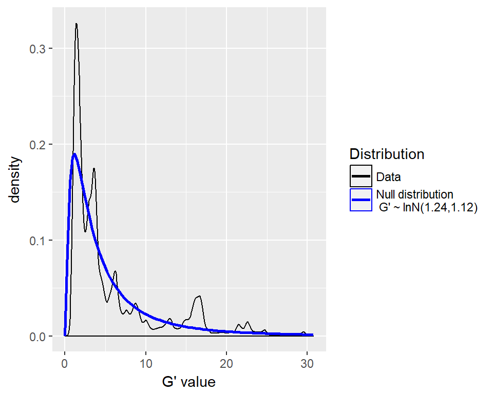

```r
plotGprimeDist(SNPset = df_filt, outlierFilter = "Hampel")
```

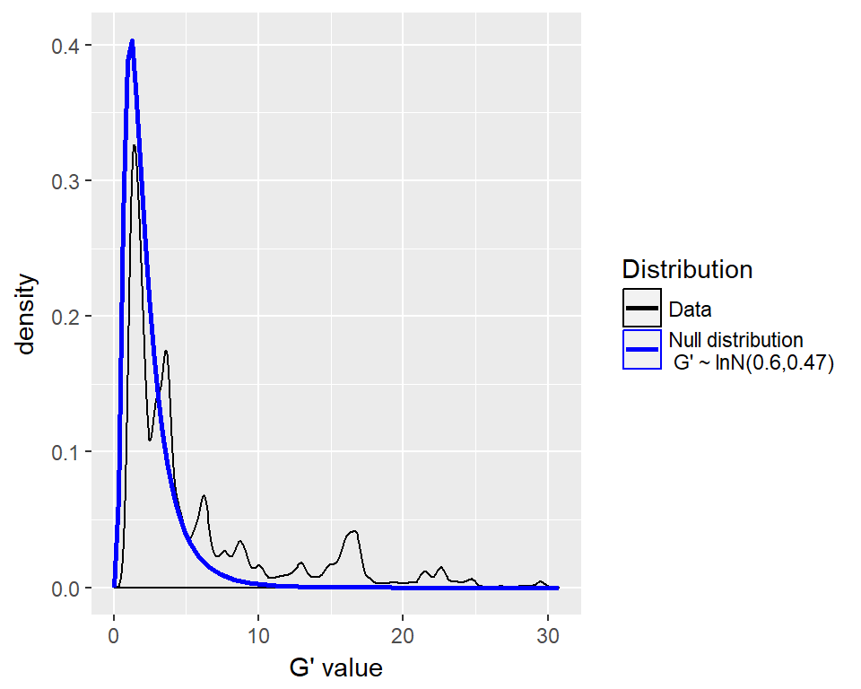

```r
plotGprimeDist(SNPset =df_filt, outlierFilter = "deltaSNP", filterThreshold = 0.1)
```

### QTL analysis plots

Now that we are happy with our filtered data and it seems that the $G'$ distribution is close to lognormal, we can finally plot some genome-wide figures and try to identify QTL.

Let’s start by plotting the SNP/window distribution:

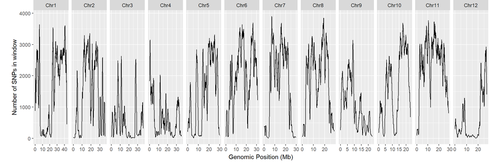

```r
p1 <- plotQTLStats(SNPset = df_filt, var = "nSNPs")
p1
```

This is informative as we can assess if there are regions with extremely low SNP density.

More importantly lets identify some QTL by plotting the smoothed $\Delta SNP\text{-}index$ and $G'$ values.

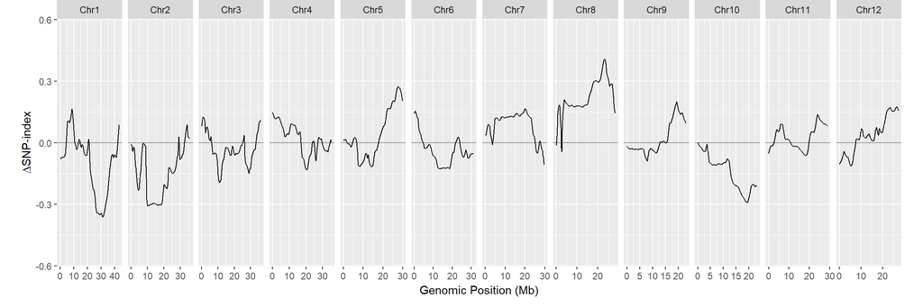

```r
p2 <- plotQTLStats(SNPset = df_filt, var = "deltaSNP")
p2
```

We can see that there are some regions that have $|\Delta SNP\text{-}index| > 0.3$ these may be QTL. The directionality of the $\Delta SNP\text{-}index$ is also important. If the allele contributing to the trait is from the reference parent the $\Delta SNP\text{-}index$ should be less than 0. However, if the $\Delta SNP\text{-}index > 0$ then the contributing parent is the one with the alternate alleles.

Let’s look at the $G'$ values to see if these regions are significant and pass the FDR (q) of 0.01.

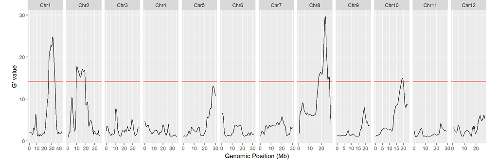

```r
p3 <- plotQTLStats(SNPset = df_filt, var = "Gprime", plotThreshold = TRUE, q = 0.01)
p3
```

We can also use the `plotQTLStats` function to the $-log_{10}(p\text{-}value)$. While this number is a direct dirivitive of $G'$ it can be more self explanitory for some. We can use the subset paramater to plot one or a few of the chomosomes, say for a close up figure of a QTL of interest. Here we look at the $-log_{10}(p\text{-}value)$ plots of Chromosomes 1 and 8:

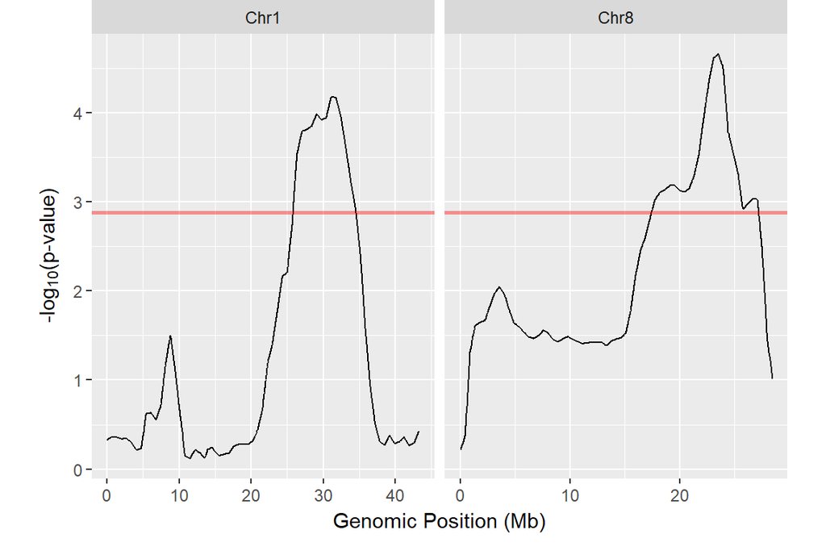

```r
QTLplots <- plotQTLStats(SNPset = df_filt, var = "negLog10Pval", plotThreshold = TRUE, q = 0.01, subset = c("Chr1", "Chr8"))
QTLplots
```

## Extracting QTL data

Now that we’ve plotted and identified some putative QTL we can extract the data using two functions `getSigRegions` and `getQTLTable`.

### Extracting significant regions

Let’s examine the `head` of the first QTL:

```r
QTL <- getSigRegions(SNPset = df_filt, alpha = 0.01)
head(QTL[[1]])
```

```
##       CHROM      POS REF ALT DP.HIGH AD_REF.HIGH AD_ALT.HIGH GQ.HIGH
## 24895  Chr1 25842439   T   C     105          58          47      99
## 24896  Chr1 25844940   A   G     126          74          52      99
## 24897  Chr1 25846683   A   G      78          48          30      99
## 24898  Chr1 25847043   G   A     180          90          90      99
## 24899  Chr1 25849237   G   A      50          30          20      99
## 24900  Chr1 25851646   A   T      61          35          26      99
##       SNPindex.HIGH DP.LOW AD_REF.LOW AD_ALT.LOW GQ.LOW SNPindex.LOW
## 24895     0.4476190     80         21         59     99    0.7375000
## 24896     0.4126984     79         20         59     99    0.7468354
## 24897     0.3846154     63         16         47     99    0.7460317
## 24898     0.5000000     87         26         61     99    0.7011494
## 24899     0.4000000     58         12         46     99    0.7931034
## 24900     0.4262295     53         12         41     99    0.7735849
##         REF_FRQ   deltaSNP nSNPs tricubeDeltaSNP         G   Gprime
## 24895 0.4270270 -0.2898810  1068      -0.2762683 15.998496 14.52061
## 24896 0.4585366 -0.3341370  1065      -0.2764951 22.572856 14.54205
## 24897 0.4539007 -0.3614164  1055      -0.2766532 18.929521 14.55700
## 24898 0.4344569 -0.2011494  1055      -0.2766858  9.885982 14.56008
## 24899 0.3888889 -0.3931034  1054      -0.2768848 17.901883 14.57889
## 24900 0.4122807 -0.3473554  1052      -0.2771032 14.579060 14.59955
##            pvalue negLog10Pval      qvalue
## 24895 0.001185737     2.926012 0.009145189
## 24896 0.001177278     2.929121 0.009096584
## 24897 0.001171423     2.931286 0.009060519
## 24898 0.001170218     2.931733 0.009052934
## 24899 0.001162903     2.934457 0.009008602
## 24900 0.001154930     2.937444 0.008962478
```

### Output QTL summary

While `getSigRegions` is useful for examining every SNP within each QTL and perhaps for some downstream analysis, the `getQTLTable` will summarize those results and can output a CSV by setting `export = TRUE` and `fileName = "MyQTLsummary.csv"`.

Here is the summary for significant regions with a FDR of 0.01:

```r
results <- getQTLTable(SNPset = df_filt, alpha = 0.01, export = FALSE)
results
```

```
##   id Chromosome    start      end  length nSNPs avgSNPs_Mb meanGprime
## 1  1       Chr1 25842439 34556923 8714484 20263       2325   21.29574
## 2  2       Chr2  9575918 19411590 9835672 24267       2467   16.44684
## 3  3       Chr8 17427057 27196250 9769193 20529       2101   18.89438
## 4  4      Chr10 18619373 19792840 1173467  3590       3059   14.68470
##    sdGprime      AUCaT     meanPval    meanQval
## 1 2.6768852 60704185.7 0.0002362947 0.005050808
## 2 0.6348595 22256829.6 0.0006525797 0.007346565
## 3 4.6368929 46533829.4 0.0005309317 0.006606070
## 4 0.2098474   577793.3 0.0011258224 0.008877309
```

## Summary

We’ve reviewed how to load SNP data from GATK and filter the data to contain high confidence SNPs. We then performed $\Delta SNP\text{-}index$ and $G'$ analysis and calculate p-values and q-values based on the tricube-smoothed $G'$ values. The QTL regions that pass our defined threshold can be stored as a list for further analysis or summarized as a table for publication.